```python
# Downloading and importing all the necessary libraries to complete the project.
import tweepy
import pandas as pd
import matplotlib.pyplot as plt
import numpy as np
import seaborn as sns
import requests
import json
import os
import re
import warnings
warnings.simplefilter('ignore')
```

```python
from PIL import Image
from wordcloud import WordCloud, STOPWORDS, ImageColorGenerator
```

```python
pd.set_option('display.max_colwidth', -1)
```

# Gather

> First table archive downloaded from the internet manually and programmatically opened into a pandas DataFrame.

```python
archive = pd.read_csv('twitter-archive-enhanced.csv')
```

> Second table tweet_count downloaded programmatically from twitter's API using tweepy, then saved to a JSON file, stored in a dictionary, then loaded into a pandas DataFrame.

```python
from tweepy import OAuthHandler
from timeit import default_timer as timer
```

```python
consumer_key = 'HIDDEN'
consumer_secret = 'HIDDEN'
access_token = 'HIDDEN'
access_secret = 'HIDDEN'

auth = OAuthHandler(consumer_key, consumer_secret)
auth.set_access_token(access_token, access_secret)

api = tweepy.API(auth, wait_on_rate_limit=True)

tweet_ids = archive.tweet_id.values
len(tweet_ids)
```

```
2356
```

```python
# set a function for tweet extraction
# file already created so no need to execute to continue the notebook
def tweet_extraction():
    count = 0
    fails_dict = {}
    start = timer()
    with open('tweet_json.txt', 'w') as outfile:
        for tweet_id in tweet_ids:
            count += 1
            print(str(count) + ": " + str(tweet_id))
            try:
                tweet = api.get_status(tweet_id, tweet_mode='extended')
                print("Success")
                json.dump(tweet._json, outfile)
                outfile.write('\n')
            except tweepy.TweepError as e:
                print("Fail")
                fails_dict[tweet_id] = e
                pass
    end = timer()
    print(end - start)
    print(fails_dict)
```

```python
df_list = []
with open('tweet_json.txt') as file:
    for line in file:
        data = json.loads(line)
        keys = data.keys()
        user = data.get('user')
        id_str = data.get('id_str')
        retweet_count = data.get('retweet_count')
        favorite_count = data.get('favorite_count')
        df_list.append({'id_str': id_str,
                        'retweet_count': retweet_count,
                        'favorite_count': favorite_count})
```

[output not shown]

```python
tweet_count = pd.DataFrame(df_list, columns = ['id_str', 'retweet_count', 'favorite_count'])
```

[output not shown]

```python
tweet_count.head()
```

> Third table, programmatically downloaded from the Udacity servers and stored in a folder image_pred, then written to local computer and loaded into a pandas DataFrame.

```python
# Downloading the image predictions from the internet
folder_name = 'image_pred'
if not os.path.exists(folder_name):
    os.makedirs(folder_name)

url = 'https://d17h27t6h515a5.cloudfront.net/topher/2017/August/599fd2ad_image-predictions/image-predictions.tsv'
response = requests.get(url)
```

```python
with open(os.path.join(folder_name, url.split('/')[-1]), mode='wb') as file:
    file.write(response.content)
```

```python
image_pred = pd.read_csv('image_predictions.tsv', sep='\t')
```

# Assessing Data

### Visual

```python
archive.head()
```

```python
archive.text.sample(20)
```

```
1001    Pls don't send more sherks. I don't care how seemingly floofy they are. It does me so much frighten. Thank u. 11/10 https://t.co/oQqlOsla4R
2020    This is Tuco. That's the toast that killed his father. 9/10 https://t.co/ujnWy26RMe
1407    Meet Reagan. He's a Persnicketus Derpson. Great with kids. Permanently caught off guard. 8/10 https://t.co/A2j2StfNgL
1124    This is Ziva. She doesn't know how her collar works. 11/10 would totally fix for her https://t.co/K7pthJXjWE
383     This is Charlie. He wins every game of chess he plays. Won't let opponent pet him until they forfeit. 13/10 you win again Charlie https://t.co/UkyQibIBzZ
578     Say hello to Mauve and Murphy. They're rather h*ckin filthy. Preferred nap over bath. Both 12/10 https://t.co/4UwCTW3lXG
1667    Meet Joey and Izzy. Joey only has one ear that works and Izzy wants 2015 to be over already. Both great pups. 11/10s https://t.co/WgQTIQ93BB
2087    This is Trigger. He was minding his own business on stair when he overheard someone say they don't like bacon. 11/10 https://t.co/yqohZK4CL0
2325    This is Walter. He is an Alaskan Terrapin. Loves outdated bandanas. One ear still working. Cool house plant. 10/10 https://t.co/qXpcwENTvn
539     Hooman catch successful. Massive hit by dog. Fumble ensued. Possession to dog. 13/10 https://t.co/QrFkqgHR1G
773     RT @dog_rates: We only rate dogs. Pls stop sending in non-canines like this Mongolian grass snake. This is very frustrating. 11/10 https://…
783     This is Maximus. A little rain won't stop him. He will persevere. 12/10 innovative af  https://t.co/2OmDMAkkou
2016    This is Bradley. That is his sandwich. He carries it everywhere. 10/10 https://t.co/AjBkGTyCeO
1139    This is Rueben. He has reached ultimate pupper zen state. 11/10 tranquil af https://t.co/Z167HgtnBi
1069    When the photographer forgets to tell you where to look... 10/10 https://t.co/u1GHWxhC85
1528    This is Oddie. He's trying to communicate. 12/10 very solid effort (vid by @kaleseyy) https://t.co/JjxriLqZOL
1405    "I'm bathing the children what do you want?"  ...both 10/10 https://t.co/Rizm1LWh4z
1752    Meet Lola. She's a Metamorphic Chartreuse. Plays with her food. Insubordinate and churlish. Exquisite hardwood 11/10 https://t.co/etpBNXwN7f
350     This is Dutch. He dressed up as his favorite emoji for Valentine's Day. I've got heart eyes for his heart eyes. 13/10 https://t.co/BCbmFYLrse
53      This is Rey. He's a Benebop Cumberfloof. 12/10 dangerously pettable https://t.co/503CgWbhxQ
Name: text, dtype: object
```

```python
image_pred.head()
```

|  | tweet_id | jpg_url | img_num | p1 | p1_conf | p1_dog | p2 | p2_conf | p2_dog | p3 | p3_conf | p3_dog |
| --- | --- | --- | --- | --- | --- | --- | --- | --- | --- | --- | --- | --- |
| 0 | 666020888022790149 | https://pbs.twimg.com/media/CT4udn0WwAA0aMy.jpg | 1 | Welsh_springer_spaniel | 0.465074 | True | collie | 0.156665 | True | Shetland_sheepdog | 0.061428 | True |
| 1 | 666029285002620928 | https://pbs.twimg.com/media/CT42GRgUYAA5iDo.jpg | 1 | redbone | 0.506826 | True | miniature_pinscher | 0.074192 | True | Rhodesian_ridgeback | 0.072010 | True |
| 2 | 666033412701032449 | https://pbs.twimg.com/media/CT4521TWwAEvMyu.jpg | 1 | German_shepherd | 0.596461 | True | malinois | 0.138584 | True | bloodhound | 0.116197 | True |
| 3 | 666044226329800704 | https://pbs.twimg.com/media/CT5Dr8HUEAA-lEu.jpg | 1 | Rhodesian_ridgeback | 0.408143 | True | redbone | 0.360687 | True | miniature_pinscher | 0.222752 | True |
| 4 | 666049248165822465 | https://pbs.twimg.com/media/CT5IQmsXIAAKY4A.jpg | 1 | miniature_pinscher | 0.560311 | True | Rottweiler | 0.243682 | True | Doberman | 0.154629 | True |

### Quality

#### archive table

- Missing values in columns: in_reply_to_status_id, in_reply_to_user_id, retweeted_status_id, retweeted_status_user_id, retweeted_status_timestamp, and expanded_urls.
- Column name floofer should be spelled 'floof'

#### image-pred Table

- The types of dogs in columns p1, p2, and p3 had some uppercase and lowercase letters.

### Tidiness

- The column text had multiple variables like a url link, rating, and some tweets represented two dogs.
- The tweet_count and archive table should be merged as this is related data.

*Programmatic*

```python
archive.info()
```

```
<class 'pandas.core.frame.DataFrame'>
RangeIndex: 2356 entries, 0 to 2355
Data columns (total 17 columns):
tweet_id                      2356 non-null int64
in_reply_to_status_id         78 non-null float64
in_reply_to_user_id           78 non-null float64
timestamp                     2356 non-null object
source                        2356 non-null object
text                          2356 non-null object
retweeted_status_id           181 non-null float64
retweeted_status_user_id      181 non-null float64
retweeted_status_timestamp    181 non-null object
expanded_urls                 2297 non-null object
rating_numerator              2356 non-null int64
rating_denominator            2356 non-null int64
name                          2356 non-null object
doggo                         2356 non-null object
floofer                       2356 non-null object
pupper                        2356 non-null object
puppo                         2356 non-null object
dtypes: float64(4), int64(3), object(10)
memory usage: 313.0+ KB
```

- tweet_id has dtype int64 and should be object
- **timestamp** should be a datetime64 dtype type as well

```python
doggo = archive.doggo.value_counts()
floofer = archive.floofer.value_counts()
pupper = archive.pupper.value_counts()
puppo = archive.puppo.value_counts()
print(doggo);
print(floofer);
print(pupper);
print(puppo)
```

```
None     2259
doggo    97
Name: doggo, dtype: int64
None       2346
floofer    10
Name: floofer, dtype: int64
None      2099
pupper    257
Name: pupper, dtype: int64
None     2326
puppo    30
Name: puppo, dtype: int64
```

> - Misssing information for the dog stages

```python
archive.name.value_counts().head(20)
```

```
None       745
a          55
Charlie    12
Cooper     11
Oliver     11
Lucy       11
Lola       10
Tucker     10
Penny      10
Bo         9
Winston    9
the        8
Sadie      8
Buddy      7
Daisy      7
Toby       7
an         7
Bailey     7
Bella      6
Rusty      6
Name: name, dtype: int64
```

> Many missing names from the list under 'None', and random names like 'a' and 'an' might be parts of strings that got taken out of context.

```python
archive.source.value_counts()
```

```
<a href="http://twitter.com/download/iphone" rel="nofollow">Twitter for iPhone</a>     2221
<a href="http://vine.co" rel="nofollow">Vine - Make a Scene</a>                        91
<a href="http://twitter.com" rel="nofollow">Twitter Web Client</a>                     33
<a href="https://about.twitter.com/products/tweetdeck" rel="nofollow">TweetDeck</a>    11
Name: source, dtype: int64
```

> The source column looks messy and clutters the table

```python
tweet_count.info()
```

```
<class 'pandas.core.frame.DataFrame'>
Index: 0 entries
Data columns (total 3 columns):
id_str            0 non-null object
retweet_count     0 non-null object
favorite_count    0 non-null object
dtypes: object(3)
memory usage: 0.0+ bytes
```

```python
image_pred.info()
```

```
<class 'pandas.core.frame.DataFrame'>
RangeIndex: 2075 entries, 0 to 2074
Data columns (total 12 columns):
tweet_id    2075 non-null int64
jpg_url     2075 non-null object
img_num     2075 non-null int64
p1          2075 non-null object
p1_conf     2075 non-null float64
p1_dog      2075 non-null bool
p2          2075 non-null object
p2_conf     2075 non-null float64
p2_dog      2075 non-null bool
p3          2075 non-null object
p3_conf     2075 non-null float64
p3_dog      2075 non-null bool
dtypes: bool(3), float64(3), int64(2), object(4)
memory usage: 152.1+ KB
```

> The tweet_id column should be dtype object instead of int64.

**Assessment Summary**

#### Quality

*Archive Table*

- Missing values in columns: in_reply_to_status_id, in_reply_to_user_id, retweeted_status_id, retweeted_status_user_id, retweeted_status_timestamp, and expanded_urls.
- Column name floofer should be spelled 'floof'
- tweet_id has dtype int64 and should be object
- timestamp should be a datetime64 dtype type as well
- Missing information for dog stages.
- Many missing names from the list under 'None', and random names like 'a' and 'an' might be parts of strings that got taken out of context.
- Remove from table retweets and replies keepng only original tweets.
- Some tweets had "\&" combined with ";" which is the html code to display just the ampersand, so that needs to be cleaned up.

*tweet_count Table*

- The column id_str should be changed to tweet_id so merging tables will be smoother.

*image_pred Table*

- The types of dogs in columns p1, p2, and p3 had some uppercase and lowercase letters.
- The tweet_id column should be dtype object instead of int64.

*Tidiness*

- The tweet_count and archive table should be merged as this is added data to the other table.
- The source column in archive table looks messy and clutters the table.
- All three tables will eventually be merged into one.

# Cleaning Data

Make copies of each table first before cleaning, as to help reduce catastrophe

```python
# trimmed the names in order to make less wordy when coding
archive_clean = archive.copy()
image_clean = image_pred.copy()
tweet_clean = tweet_count.copy()
```

# 1 archive: remove from table retweets and replies keeping only original tweets

**Define**

Find the retweets and replies using the retweeted_status_id and in_reply_to_status_id columns and remove from the DataFrame

**Code**

```python
drop_retweet = archive_clean[pd.notnull(archive_clean['retweeted_status_id'])].index
drop_reply = archive_clean[pd.notnull(archive_clean['in_reply_to_status_id'])].index
```

```python
archive_clean.drop(index=drop_retweet, inplace=True)
archive_clean.drop(index=drop_reply, inplace=True)
```

**Test**

```python
archive_clean.info()
```

```
<class 'pandas.core.frame.DataFrame'>
Int64Index: 2097 entries, 0 to 2355
Data columns (total 17 columns):
tweet_id                      2097 non-null int64
in_reply_to_status_id         0 non-null float64
in_reply_to_user_id           0 non-null float64
timestamp                     2097 non-null object
source                        2097 non-null object
text                          2097 non-null object
retweeted_status_id           0 non-null float64
retweeted_status_user_id      0 non-null float64
retweeted_status_timestamp    0 non-null object
expanded_urls                 2094 non-null object
rating_numerator              2097 non-null int64
rating_denominator            2097 non-null int64
name                          2097 non-null object
doggo                         2097 non-null object
floofer                       2097 non-null object
pupper                        2097 non-null object
puppo                         2097 non-null object
dtypes: float64(4), int64(3), object(10)
memory usage: 294.9+ KB
```

# 2 archive: Missing values in columns and unnecessary columns

**Define**

Remove columns with missing values using dropna() method. Also, use the drop() method to drop source column from table as well

**Code**

```python
archive_clean.dropna(axis='columns',how='any', inplace=True)
```

```python
archive_clean.drop(columns='source', inplace=True)
```

**Test**

```python
archive_clean.head()
```

|  | tweet_id | timestamp | text | rating_numerator | rating_denominator | name | doggo | floofer | pupper | puppo |
| --- | --- | --- | --- | --- | --- | --- | --- | --- | --- | --- |
| 0 | 892420643555336193 | 2017-08-01 16:23:56 +0000 | This is Phineas. He's a mystical boy. Only ever appears in the hole of a donut. 13/10 https://t.co/MgUWQ76dJU | 13 | 10 | Phineas | None | None | None | None |
| 1 | 892177421306343426 | 2017-08-01 00:17:27 +0000 | This is Tilly. She's just checking pup on you. Hopes you're doing ok. If not, she's available for pats, snugs, boops, the whole bit. 13/10 https://t.co/0Xxu71qeIV | 13 | 10 | Tilly | None | None | None | None |
| 2 | 891815181378084864 | 2017-07-31 00:18:03 +0000 | This is Archie. He is a rare Norwegian Pouncing Corgo. Lives in the tall grass. You never know when one may strike. 12/10 https://t.co/wUnZnhtVJB | 12 | 10 | Archie | None | None | None | None |
| 3 | 891689557279858688 | 2017-07-30 15:58:51 +0000 | This is Darla. She commenced a snooze mid meal. 13/10 happens to the best of us https://t.co/tD36da7qLQ | 13 | 10 | Darla | None | None | None | None |
| 4 | 891327558926688256 | 2017-07-29 16:00:24 +0000 | This is Franklin. He would like you to stop calling him "cute." He is a very fierce shark and should be respected as such. 12/10 #BarkWeek https://t.co/AtUZn91f7f | 12 | 10 | Franklin | None | None | None | None |

# 3 Fixing column names

> - tweet_clean: unifying column names
> - archive_clean: column names

**Define**

- In the tweet_clean table the column name id_str changed to tweet_id using the rename() function.
- In the archive_clean table, column name floofer should be "floof" to match the dog stage associated with it using the rename() function. The columns rating_numerator and rating_denominator should be shortend to "rate_num" and "rate_denom" to make it less wordy.

**Code**

```python
tweet_clean.rename(index=str, columns={"id_str": "tweet_id"}, inplace=True)
archive_clean.rename(columns={"floofer": "floof",
                                         "rating_numerator": "rate_num",
                                         "rating_denominator": "rate_denom"}, inplace=True)
```

**Test**

```python
tweet_clean.info()
```

```
<class 'pandas.core.frame.DataFrame'>
Index: 0 entries
Data columns (total 3 columns):
tweet_id          0 non-null object
retweet_count     0 non-null object
favorite_count    0 non-null object
dtypes: object(3)
memory usage: 0.0+ bytes
```

# Fixing Datatypes

> - image_clean: tweet_id dtype "string"
> - archive_clean: timestamp dtype "datetime"
> - archive_clean: tweet_id dtype "string"

**Define**

- In the image_clean table, change the dtype of column tweet_id from int64 to object using the astype() function.
- In the archive_clean table, change the dtype of column timestamp from object to datetime using pandas to_datetime() function.
- In the archive_clean table, change the dtype of column tweet_id from int64 to object using the astype() function.

**code**

```python
image_clean['tweet_id'] = image_clean['tweet_id'].astype('str')
archive_clean['timestamp'] = pd.to_datetime(archive_clean['timestamp'])
archive_clean['tweet_id'] = archive_clean['tweet_id'].astype('str')
```

**Test**

```python
image_clean.info()
```

```
<class 'pandas.core.frame.DataFrame'>
RangeIndex: 2075 entries, 0 to 2074
Data columns (total 12 columns):
tweet_id    2075 non-null object
jpg_url     2075 non-null object
img_num     2075 non-null int64
p1          2075 non-null object
p1_conf     2075 non-null float64
p1_dog      2075 non-null bool
p2          2075 non-null object
p2_conf     2075 non-null float64
p2_dog      2075 non-null bool
p3          2075 non-null object
p3_conf     2075 non-null float64
p3_dog      2075 non-null bool
dtypes: bool(3), float64(3), int64(1), object(5)
memory usage: 152.1+ KB
```

```python
archive_clean.info()
```

```
<class 'pandas.core.frame.DataFrame'>
Int64Index: 2097 entries, 0 to 2355
Data columns (total 10 columns):
tweet_id      2097 non-null object
timestamp     2097 non-null datetime64[ns]
text          2097 non-null object
rate_num      2097 non-null int64
rate_denom    2097 non-null int64
name          2097 non-null object
doggo         2097 non-null object
floof         2097 non-null object
pupper        2097 non-null object
puppo         2097 non-null object
dtypes: datetime64[ns](1), int64(2), object(7)
memory usage: 180.2+ KB
```

# 5 image_clean: dog breeds uniformity

**Define**

In the image_clean table, the dogbreeds in the p1, p2, and p3 are converting all the names to lowercase letters.

**Code**

```python
image_clean['p1'] = image_clean['p1'].str.lower()
image_clean['p2'] = image_clean['p2'].str.lower()
image_clean['p3'] = image_clean['p3'].str.lower()
```

**Test**

```python
image_clean.p1.head()
```

```
0    welsh_springer_spaniel
1    redbone
2    german_shepherd
3    rhodesian_ridgeback
4    miniature_pinscher
Name: p1, dtype: object
```

```python
image_clean.p2.head()
```

```
0    collie
1    miniature_pinscher
2    malinois
3    redbone
4    rottweiler
Name: p2, dtype: object
```

```python
image_clean.p3.head()
```

```
0    shetland_sheepdog
1    rhodesian_ridgeback
2    bloodhound
3    miniature_pinscher
4    doberman
Name: p3, dtype: object
```

# 6 archive_clean: clean up text column

**Define**

- In the archive_clean table, change the html ampersand code from "& ;" to "&" in the text column
- Remove the "/n " the newline symbol
- Remove ending url link.

**Code**

```python
archive_clean['text'] = archive_clean.text.str.replace("&amp;", "&")
archive_clean['text'] = archive_clean.text.str.replace("\n", " ")
archive_clean['text'] = archive_clean.text.str.replace(r"http\S+", "")
archive_clean['text'] = archive_clean.text.str.strip()
```

**Test**

```python
archive_clean.query("text == '&amp;'")
```

|  | tweet_id | timestamp | text | rate_num | rate_denom | name | doggo | floof | pupper | puppo |
| --- | --- | --- | --- | --- | --- | --- | --- | --- | --- | --- |

```python
archive_clean.iloc[[588, 797, 853, 948, 985, 1005, 1136, 1234, 1239, 1278,
                    1294, 1307, 1426, 1556, 1592, 1649, 1653, 1719, 1759,
                    1811, 1860, 1922, 1960, 2005, 2014, 2047, 2076], [2,3,4,5]]
```

|  | text | rate_num | rate_denom | name |
| --- | --- | --- | --- | --- |
| 766 | "Yep... just as I suspected. You're not flossing." 12/10 and 11/10 for the pup not flossing | 12 | 10 | None |
| 1007 | This is Bookstore and Seaweed. Bookstore is tired and Seaweed is an asshole. 10/10 and 7/10 respectively | 10 | 10 | Bookstore |
| 1068 | After so many requests, this is Bretagne. She was the last surviving 9/11 search dog, and our second ever 14/10. RIP | 9 | 11 | None |
| 1165 | Happy 4/20 from the squad! 13/10 for all | 4 | 20 | None |
| 1202 | This is Bluebert. He just saw that both #FinalFur match ups are split 50/50. Amazed af. 11/10 | 50 | 50 | Bluebert |
| 1222 | Meet Travis and Flurp. Travis is pretty chill but Flurp can't lie down properly. 10/10 & 8/10 get it together Flurp | 10 | 10 | Travis |
| 1359 | This is Socks. That water pup w the super legs just splashed him. Socks did not appreciate that. 9/10 and 2/10 | 9 | 10 | Socks |
| 1459 | This may be the greatest video I've ever been sent. 4/10 for Charles the puppy, 13/10 overall. (Vid by @stevenxx_) | 4 | 10 | None |
| 1465 | Meet Oliviér. He takes killer selfies. Has a dog of his own. It leaps at random & can't bark for shit. 10/10 & 5/10 | 10 | 10 | Oliviér |
| 1508 | When bae says they can't go out but you see them with someone else that same night. 5/10 & 10/10 for heartbroken pup | 5 | 10 | None |
| 1525 | This is Eriq. His friend just reminded him of last year's super bowl. Not cool friend 10/10 for Eriq 6/10 for friend | 10 | 10 | Eriq |
| 1538 | Meet Fynn & Taco. Fynn is an all-powerful leaf lord and Taco is in the wrong place at the wrong time. 11/10 & 10/10 | 11 | 10 | Fynn |
| 1662 | This is Darrel. He just robbed a 7/11 and is in a high speed police chase. Was just spotted by the helicopter 10/10 | 7 | 11 | Darrel |
| 1795 | Meet Tassy & Bee. Tassy is pretty chill, but Bee is convinced the Ruffles are haunted. 10/10 & 11/10 respectively | 10 | 10 | Tassy |
| 1832 | These two pups just met and have instantly bonded. Spectacular scene. Mesmerizing af. 10/10 and 7/10 for blue dog | 10 | 10 | None |
| 1897 | Meet Rufio. He is unaware of the pink legless pupper wrapped around him. Might want to get that checked 10/10 & 4/10 | 10 | 10 | Rufio |
| 1901 | Two gorgeous dogs here. Little waddling dog is a rebel. Refuses to look at camera. Must be a preteen. 5/10 & 8/10 | 5 | 10 | None |
| 1970 | Meet Eve. She's a raging alcoholic 8/10 (would b 11/10 but pupper alcoholism is a tragic issue that I can't condone) | 8 | 10 | Eve |
| 2010 | 10/10 for dog. 7/10 for cat. 12/10 for human. Much skill. Would pet all | 10 | 10 | None |
| 2064 | Meet Holly. She's trying to teach small human-like pup about blocks but he's not paying attention smh. 11/10 & 8/10 | 11 | 10 | Holly |
| 2113 | Meet Hank and Sully. Hank is very proud of the pumpkin they found and Sully doesn't give a shit. 11/10 and 8/10 | 11 | 10 | Hank |
| 2177 | Here we have Pancho and Peaches. Pancho is a Condoleezza Gryffindor, and Peaches is just an asshole. 10/10 & 7/10 | 10 | 10 | None |
| 2216 | This is Spark. He's nervous. Other dog hasn't moved in a while. Won't come when called. Doesn't fetch well 8/10&1/10 | 8 | 10 | Spark |
| 2263 | This is Kial. Kial is either wearing a cape, which would be rad, or flashing us, which would be rude. 10/10 or 4/10 | 10 | 10 | Kial |
| 2272 | Two dogs in this one. Both are rare Jujitsu Pythagoreans. One slightly whiter than other. Long legs. 7/10 and 8/10 | 7 | 10 | None |
| 2306 | These are Peruvian Feldspars. Their names are Cupit and Prencer. Both resemble Rand Paul. Sick outfits 10/10 & 10/10 | 10 | 10 | None |
| 2335 | This is an Albanian 3 1/2 legged Episcopalian. Loves well-polished hardwood flooring. Penis on the collar. 9/10 | 1 | 2 | an |

# 7 archive_clean: fix some of the ratings columns

**Define**

In the archive_clean table, use several methods such as extractall(), query(), contains(), etc to check for misextraction of the ratings.

**Code**

```python
archive_clean.reset_index(inplace=True, drop=True)
```

```python
archive_clean[archive_clean.text.str.contains(r"(\d+\.\d*\/\d+)")][['text', 'rate_num']]
```

|  | text | rate_num |
| --- | --- | --- |
| 41 | This is Bella. She hopes her smile made you smile. If not, she is also offering you her favorite monkey. 13.5/10 | 5 |
| 528 | This is Logan, the Chow who lived. He solemnly swears he's up to lots of good. H*ckin magical af 9.75/10 | 75 |
| 586 | This is Sophie. She's a Jubilant Bush Pupper. Super h*ckin rare. Appears at random just to smile at the locals. 11.27/10 would smile back | 27 |
| 1474 | Here we have uncovered an entire battalion of holiday puppers. Average of 11.26/10 | 26 |

```python
hyphen_table = archive_clean.text.str.extractall(r"(\d+\d*\/\d+)")
hyphen_table.head(10)
```

|  | match | 0 |
| --- | --- | --- |
| 0 | 0 | 13/10 |
| 1 | 0 | 13/10 |
| 2 | 0 | 12/10 |
| 3 | 0 | 13/10 |
| 4 | 0 | 12/10 |
| 5 | 0 | 13/10 |
| 6 | 0 | 13/10 |
| 7 | 0 | 13/10 |
| 8 | 0 | 13/10 |
| 9 | 0 | 14/10 |

```python
match_1 = hyphen_table.query("match == 1")
match_1.head()
```

|  | match | 0 |
| --- | --- | --- |
| 588 | 1 | 11/10 |
| 797 | 1 | 7/10 |
| 853 | 1 | 14/10 |
| 948 | 1 | 13/10 |
| 985 | 1 | 11/10 |

```python
match_1.index.labels
```

```
FrozenList([[588, 797, 853, 948, 985, 1005, 1136, 1234, 1239, 1278, 1294, 1307, 1426, 1556, 1592, 1649, 1653, 1719, 1759, 1811, 1860, 1922, 1960, 2005, 2014, 2047, 2076], [1, 1, 1, 1, 1, 1, 1, 1, 1, 1, 1, 1, 1, 1, 1, 1, 1, 1, 1, 1, 1, 1, 1, 1, 1, 1, 1]])
```

```python
# copied indices from above
archive_clean.iloc[[588, 797, 853, 948, 985, 1005, 1136, 1234, 1239, 1278,
                    1294, 1307, 1426, 1556, 1592, 1649, 1653, 1719, 1759,
                    1811, 1860, 1922, 1960, 2005, 2014, 2047, 2076], [2,3,4,5]]
```

|  | text | rate_num | rate_denom | name |
| --- | --- | --- | --- | --- |
| 588 | "Yep... just as I suspected. You're not flossing." 12/10 and 11/10 for the pup not flossing | 12 | 10 | None |
| 797 | This is Bookstore and Seaweed. Bookstore is tired and Seaweed is an asshole. 10/10 and 7/10 respectively | 10 | 10 | Bookstore |
| 853 | After so many requests, this is Bretagne. She was the last surviving 9/11 search dog, and our second ever 14/10. RIP | 9 | 11 | None |
| 948 | Happy 4/20 from the squad! 13/10 for all | 4 | 20 | None |
| 985 | This is Bluebert. He just saw that both #FinalFur match ups are split 50/50. Amazed af. 11/10 | 50 | 50 | Bluebert |
| 1005 | Meet Travis and Flurp. Travis is pretty chill but Flurp can't lie down properly. 10/10 & 8/10 get it together Flurp | 10 | 10 | Travis |
| 1136 | This is Socks. That water pup w the super legs just splashed him. Socks did not appreciate that. 9/10 and 2/10 | 9 | 10 | Socks |
| 1234 | This may be the greatest video I've ever been sent. 4/10 for Charles the puppy, 13/10 overall. (Vid by @stevenxx_) | 4 | 10 | None |
| 1239 | Meet Oliviér. He takes killer selfies. Has a dog of his own. It leaps at random & can't bark for shit. 10/10 & 5/10 | 10 | 10 | Oliviér |
| 1278 | When bae says they can't go out but you see them with someone else that same night. 5/10 & 10/10 for heartbroken pup | 5 | 10 | None |
| 1294 | This is Eriq. His friend just reminded him of last year's super bowl. Not cool friend 10/10 for Eriq 6/10 for friend | 10 | 10 | Eriq |
| 1307 | Meet Fynn & Taco. Fynn is an all-powerful leaf lord and Taco is in the wrong place at the wrong time. 11/10 & 10/10 | 11 | 10 | Fynn |
| 1426 | This is Darrel. He just robbed a 7/11 and is in a high speed police chase. Was just spotted by the helicopter 10/10 | 7 | 11 | Darrel |
| 1556 | Meet Tassy & Bee. Tassy is pretty chill, but Bee is convinced the Ruffles are haunted. 10/10 & 11/10 respectively | 10 | 10 | Tassy |
| 1592 | These two pups just met and have instantly bonded. Spectacular scene. Mesmerizing af. 10/10 and 7/10 for blue dog | 10 | 10 | None |
| 1649 | Meet Rufio. He is unaware of the pink legless pupper wrapped around him. Might want to get that checked 10/10 & 4/10 | 10 | 10 | Rufio |
| 1653 | Two gorgeous dogs here. Little waddling dog is a rebel. Refuses to look at camera. Must be a preteen. 5/10 & 8/10 | 5 | 10 | None |
| 1719 | Meet Eve. She's a raging alcoholic 8/10 (would b 11/10 but pupper alcoholism is a tragic issue that I can't condone) | 8 | 10 | Eve |
| 1759 | 10/10 for dog. 7/10 for cat. 12/10 for human. Much skill. Would pet all | 10 | 10 | None |
| 1811 | Meet Holly. She's trying to teach small human-like pup about blocks but he's not paying attention smh. 11/10 & 8/10 | 11 | 10 | Holly |
| 1860 | Meet Hank and Sully. Hank is very proud of the pumpkin they found and Sully doesn't give a shit. 11/10 and 8/10 | 11 | 10 | Hank |
| 1922 | Here we have Pancho and Peaches. Pancho is a Condoleezza Gryffindor, and Peaches is just an asshole. 10/10 & 7/10 | 10 | 10 | None |
| 1960 | This is Spark. He's nervous. Other dog hasn't moved in a while. Won't come when called. Doesn't fetch well 8/10&1/10 | 8 | 10 | Spark |
| 2005 | This is Kial. Kial is either wearing a cape, which would be rad, or flashing us, which would be rude. 10/10 or 4/10 | 10 | 10 | Kial |
| 2014 | Two dogs in this one. Both are rare Jujitsu Pythagoreans. One slightly whiter than other. Long legs. 7/10 and 8/10 | 7 | 10 | None |
| 2047 | These are Peruvian Feldspars. Their names are Cupit and Prencer. Both resemble Rand Paul. Sick outfits 10/10 & 10/10 | 10 | 10 | None |
| 2076 | This is an Albanian 3 1/2 legged Episcopalian. Loves well-polished hardwood flooring. Penis on the collar. 9/10 | 1 | 2 | an |

```python
#rating confused with 9/11(September 11th)
archive_clean.iloc[853, 3] = 14
archive_clean.iloc[853, 4] = 10

#rating confused with 4/20(Weed Day)
archive_clean.iloc[948, 3] = 13
archive_clean.iloc[948, 4] = 10

#rating confused with phrase 50/50 split
archive_clean.iloc[985, 3] = 11
archive_clean.iloc[985, 4] = 10

#rating confused with 7/11 which is name of convience store
archive_clean.iloc[1426, 3] = 10
archive_clean.iloc[1426, 4] = 10

#rating confused with 1/2 representing "half"
archive_clean.iloc[2076, 3] = 9
archive_clean.iloc[2076, 4] = 10
```

```python
doubles_list = archive_clean.iloc[[588, 797, 1005, 1136, 1234, 1239, 1278,
                    1294, 1307, 1556, 1592, 1649, 1653, 1719, 1759,
                    1811, 1860, 1922, 1960, 2005, 2014, 2047]]
double_index = doubles_list.index
```

```python
archive_clean.iloc[[41, 528, 586, 1474], [2,3,4]]
```

|  | text | rate_num | rate_denom |
| --- | --- | --- | --- |
| 41 | This is Bella. She hopes her smile made you smile. If not, she is also offering you her favorite monkey. 13.5/10 | 5 | 10 |
| 528 | This is Logan, the Chow who lived. He solemnly swears he's up to lots of good. H*ckin magical af 9.75/10 | 75 | 10 |
| 586 | This is Sophie. She's a Jubilant Bush Pupper. Super h*ckin rare. Appears at random just to smile at the locals. 11.27/10 would smile back | 27 | 10 |
| 1474 | Here we have uncovered an entire battalion of holiday puppers. Average of 11.26/10 | 26 | 10 |

```python
archive_clean.iloc[41, 3] = 13.5
archive_clean.iloc[528, 3] = 9.75
archive_clean.iloc[586, 3] = 11.27
archive_clean.iloc[1474, 3] = 11.26
```

**Test**

```python
archive_clean.iloc[[45, 528, 586, 1474], [2,3,4]]
```

|  | text | rate_num | rate_denom |
| --- | --- | --- | --- |
| 45 | This is Gus. He's quite the cheeky pupper. Already perfected the disinterested wink. 12/10 would let steal my girl | 12.00 | 10 |
| 528 | This is Logan, the Chow who lived. He solemnly swears he's up to lots of good. H*ckin magical af 9.75/10 | 9.75 | 10 |
| 586 | This is Sophie. She's a Jubilant Bush Pupper. Super h*ckin rare. Appears at random just to smile at the locals. 11.27/10 would smile back | 11.27 | 10 |
| 1474 | Here we have uncovered an entire battalion of holiday puppers. Average of 11.26/10 | 11.26 | 10 |

```python
archive_clean.iloc[[853, 948, 985, 1426, 2076], [2,3,4,5]]
```

|  | text | rate_num | rate_denom | name |
| --- | --- | --- | --- | --- |
| 853 | After so many requests, this is Bretagne. She was the last surviving 9/11 search dog, and our second ever 14/10. RIP | 14.0 | 10 | None |
| 948 | Happy 4/20 from the squad! 13/10 for all | 13.0 | 10 | None |
| 985 | This is Bluebert. He just saw that both #FinalFur match ups are split 50/50. Amazed af. 11/10 | 11.0 | 10 | Bluebert |
| 1426 | This is Darrel. He just robbed a 7/11 and is in a high speed police chase. Was just spotted by the helicopter 10/10 | 10.0 | 10 | Darrel |
| 2076 | This is an Albanian 3 1/2 legged Episcopalian. Loves well-polished hardwood flooring. Penis on the collar. 9/10 | 9.0 | 10 | an |

# 8 archive_clean: removing. doubles

**Define**

- In the archive_clean table, there are some tweets with two dogs being rated, therefore those will be dropped because it violates the rules of tidiness.

**Code**

```python
doubles_list = archive_clean.iloc[[588, 797, 1005, 1136, 1234, 1239, 1278,
                    1294, 1307, 1556, 1592, 1649, 1653, 1719, 1759,
                    1811, 1860, 1922, 1960, 2005, 2014, 2047]]
double_index = doubles_list.index
```

```python
archive_clean.drop(axis='index', index=double_index, inplace=True)
```

**Test**

```python
archive_clean.info()
```

```
<class 'pandas.core.frame.DataFrame'>
Int64Index: 2075 entries, 0 to 2096
Data columns (total 10 columns):
tweet_id      2075 non-null object
timestamp     2075 non-null datetime64[ns]
text          2075 non-null object
rate_num      2075 non-null float64
rate_denom    2075 non-null int64
name          2075 non-null object
doggo         2075 non-null object
floof         2075 non-null object
pupper        2075 non-null object
puppo         2075 non-null object
dtypes: datetime64[ns](1), float64(1), int64(1), object(7)
memory usage: 178.3+ KB
```

# 9 MERGE

**Define**

Take both the archive_clean and tweet_clean tables and merge into one table using the join() method on the columns tweet_id.

**Code**

```python
df_merge1 = archive_clean.join(tweet_clean.set_index('tweet_id'), on='tweet_id')
```

**Test**

```python
df_merge1.info()
```

```
<class 'pandas.core.frame.DataFrame'>
Int64Index: 2075 entries, 0 to 2096
Data columns (total 12 columns):
tweet_id          2075 non-null object
timestamp         2075 non-null datetime64[ns]
text              2075 non-null object
rate_num          2075 non-null float64
rate_denom        2075 non-null int64
name              2075 non-null object
doggo             2075 non-null object
floof             2075 non-null object
pupper            2075 non-null object
puppo             2075 non-null object
retweet_count     0 non-null object
favorite_count    0 non-null object
dtypes: datetime64[ns](1), float64(1), int64(1), object(9)
memory usage: 210.7+ KB
```

# 10 Final Merge

**Define**

Take the newly df_merge1 table and combine with the image_clean table using the same join() method on the tweet_id column.

**Code**

```python
master = df_merge1.join(image_clean.set_index('tweet_id'), on='tweet_id')
```

**Test**

```python
master.info()
```

```
<class 'pandas.core.frame.DataFrame'>
Int64Index: 2075 entries, 0 to 2096
Data columns (total 23 columns):
tweet_id          2075 non-null object
timestamp         2075 non-null datetime64[ns]
text              2075 non-null object
rate_num          2075 non-null float64
rate_denom        2075 non-null int64
name              2075 non-null object
doggo             2075 non-null object
floof             2075 non-null object
pupper            2075 non-null object
puppo             2075 non-null object
retweet_count     0 non-null object
favorite_count    0 non-null object
jpg_url           1949 non-null object
img_num           1949 non-null float64
p1                1949 non-null object
p1_conf           1949 non-null float64
p1_dog            1949 non-null object
p2                1949 non-null object
p2_conf           1949 non-null float64
p2_dog            1949 non-null object
p3                1949 non-null object
p3_conf           1949 non-null float64
p3_dog            1949 non-null object
dtypes: datetime64[ns](1), float64(5), int64(1), object(16)
memory usage: 389.1+ KB
```

## misssing data

**Define**

Removing the missing rows from the merged tables using the drop() method.

**Code**

```python
master_copy = master.copy()
```

```python
drop_index = master_copy[pd.isnull(master_copy['jpg_url'])].index
drop_index2 = master_copy[pd.isnull(master_copy['retweet_count'])].index
drop_index, drop_index2
```

```
(Int64Index([  32,   38,   65,   73,   78,   95,  113,  153,  155,  193,
             ...
             1505, 1512, 1522, 1537, 1552, 1568, 1579, 1594, 1666, 1956],
            dtype='int64', length=126),
 Int64Index([   0,    1,    2,    3,    4,    5,    6,    7,    8,    9,
             ...
             2087, 2088, 2089, 2090, 2091, 2092, 2093, 2094, 2095, 2096],
            dtype='int64', length=2075))
```

```python
master_copy.drop(index=drop_index, inplace=True)
master_copy.drop(index=drop_index2, inplace=True)
```

[output not shown]

**Test**

```python
master_copy.info()
```

```
<class 'pandas.core.frame.DataFrame'>
Int64Index: 1949 entries, 0 to 2096
Data columns (total 23 columns):
tweet_id          1949 non-null object
timestamp         1949 non-null datetime64[ns]
text              1949 non-null object
rate_num          1949 non-null float64
rate_denom        1949 non-null int64
name              1949 non-null object
doggo             1949 non-null object
floof             1949 non-null object
pupper            1949 non-null object
puppo             1949 non-null object
retweet_count     0 non-null object
favorite_count    0 non-null object
jpg_url           1949 non-null object
img_num           1949 non-null float64
p1                1949 non-null object
p1_conf           1949 non-null float64
p1_dog            1949 non-null object
p2                1949 non-null object
p2_conf           1949 non-null float64
p2_dog            1949 non-null object
p3                1949 non-null object
p3_conf           1949 non-null float64
p3_dog            1949 non-null object
dtypes: datetime64[ns](1), float64(5), int64(1), object(16)
memory usage: 445.4+ KB
```

```python
master_copy.to_csv(path_or_buf='master.csv', index=False)
```

```python
master_clean = master_copy[['timestamp','tweet_id', 'rate_num', 'rate_denom',
                            'name', 'retweet_count', 'favorite_count', 'p1', 'p2', 'p3']]
```

# Analyzing Data

```python
#setting the DataFrame to index the timestamp column
master_copy = master_copy.set_index('timestamp')
```

```python
master_copy.sample(5)
```

| timestamp | tweet_id | text | rate_num | rate_denom | name | doggo | floof | pupper | puppo | retweet_count | ... | img_num | p1 | p1_conf | p1_dog | p2 | p2_conf | p2_dog | p3 | p3_conf | p3_dog |
| --- | --- | --- | --- | --- | --- | --- | --- | --- | --- | --- | --- | --- | --- | --- | --- | --- | --- | --- | --- | --- | --- |
| 2016-03-19 01:54:56 | 711008018775851008 | This is Chuckles. He had a balloon but he accidentally let go of it and it floated away. 11/10 hang in there pupper | 11.0 | 10 | Chuckles | None | None | pupper | None | NaN | ... | 1.0 | french_bulldog | 0.731405 | True | boston_bull | 0.150672 | True | pug | 0.021811 | True |
| 2015-11-28 05:05:47 | 670468609693655041 | This is Edd. He's a Czechoslovakian Googolplex Merlot. Ready for Christmas. Take that Starbucks. Very poised. 10/10 | 10.0 | 10 | Edd | None | None | None | None | NaN | ... | 1.0 | minivan | 0.730152 | False | beach_wagon | 0.078661 | False | car_wheel | 0.064346 | False |
| 2016-10-31 22:00:04 | 793210959003287553 | This is Maude. She's the h*ckin happiest wasp you've ever seen. 10/10 would pet with caution | 10.0 | 10 | Maude | None | None | None | None | NaN | ... | 1.0 | doormat | 0.874431 | False | french_bulldog | 0.018759 | True | boston_bull | 0.015134 | True |
| 2017-03-13 00:02:39 | 841077006473256960 | This is Dawn. She's just checking pup on you. Making sure you're doing okay. 12/10 she's here if you need her | 12.0 | 10 | Dawn | None | None | None | None | NaN | ... | 1.0 | brittany_spaniel | 0.962985 | True | blenheim_spaniel | 0.014820 | True | clumber | 0.009557 | True |
| 2016-01-21 02:56:40 | 690005060500217858 | "I'm the only one that ever does anything in this household" 10/10 | 10.0 | 10 | None | None | None | None | None | NaN | ... | 1.0 | samoyed | 0.270287 | True | great_pyrenees | 0.114027 | True | teddy | 0.072475 | False |

5 rows × 22 columns

**Basic Statistics**

```python
# viewing some descriptive statistics with the quantitative measures in our analysis.
# used round(5) in order to visually see the last two columns without scientific notation involved.
master_copy.describe().round(5)
```

|  | rate_num | rate_denom | img_num | p1_conf | p2_conf | p3_conf |
| --- | --- | --- | --- | --- | --- | --- |
| count | 1949.00000 | 1949.00000 | 1949.00000 | 1949.00000 | 1949.00000 | 1949.00000 |
| mean | 12.20615 | 10.46024 | 1.20267 | 0.59426 | 0.13431 | 0.06021 |
| std | 41.82962 | 6.82715 | 0.56094 | 0.27237 | 0.10088 | 0.05094 |
| min | 0.00000 | 7.00000 | 1.00000 | 0.04433 | 0.00000 | 0.00000 |
| 25% | 10.00000 | 10.00000 | 1.00000 | 0.36046 | 0.05296 | 0.01619 |
| 50% | 11.00000 | 10.00000 | 1.00000 | 0.58776 | 0.11740 | 0.04947 |
| 75% | 12.00000 | 10.00000 | 1.00000 | 0.84699 | 0.19540 | 0.09150 |
| max | 1776.00000 | 170.00000 | 4.00000 | 1.00000 | 0.48801 | 0.27342 |

**Correlation**

```python
# this method helps to see which variables correlate and helpful when doing a hypothesis test or A/B test.
master_copy.corr()
```

|  | rate_num | rate_denom | img_num | p1_conf | p2_conf | p3_conf |
| --- | --- | --- | --- | --- | --- | --- |
| rate_num | 1.000000 | 0.184969 | -0.002635 | -0.006098 | -0.020520 | -0.007058 |
| rate_denom | 0.184969 | 1.000000 | -0.016326 | 0.011969 | -0.038065 | -0.006542 |
| img_num | -0.002635 | -0.016326 | 1.000000 | 0.204818 | -0.158799 | -0.139215 |
| p1_conf | -0.006098 | 0.011969 | 0.204818 | 1.000000 | -0.509777 | -0.707192 |
| p2_conf | -0.020520 | -0.038065 | -0.158799 | -0.509777 | 1.000000 | 0.480561 |
| p3_conf | -0.007058 | -0.006542 | -0.139215 | -0.707192 | 0.480561 | 1.000000 |

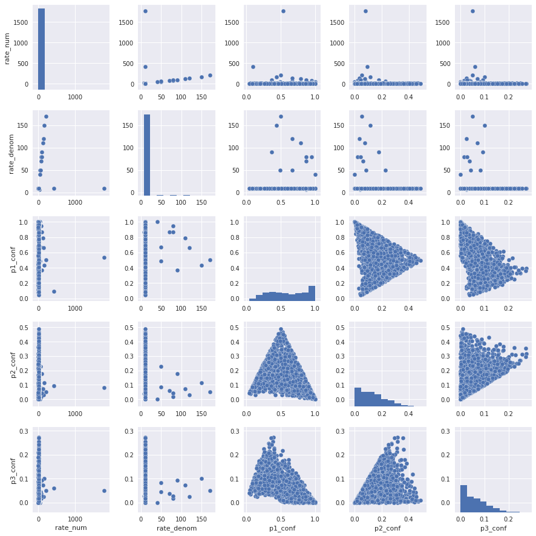

```python
sns.pairplot(master_copy, vars=["rate_num", "rate_denom", "p1_conf", "p2_conf", "p3_conf"]);
```

**Word cloud with tweets**

- A word cloud is a fun tool that lets user take the most frequently used words from a text, in this case, the tweets used in the dataset, and display in a fun image.
- The outline of a paw print was used for this word cloud in association with the @WeRateDogs twitter account that was used in the process of this project.

> First we need to create a list with all the words that were tweeted in our DataFrame.

```python
tweets = np.array(master_copy.text)
my_list = []
for tweet in tweets:
    my_list.append(tweet.replace("\n",""))
```

> Next, we downloaded an image of a paw print from the internet and used it in the function below to generate a word cloud with the tweets.

```python
mask = np.array(Image.open(requests.get('https://clipartix.com/wp-content/uploads/2016/06/Dog-bone-pink-print-dog-paw-print-transparent-background-paw-print-pink-clipart.jpg', stream=True).raw))
text = my_list
```

```python
def gen_wc(text, mask):
    word_cloud = WordCloud(width = 500, height = 500, background_color='white', mask=mask).generate(str(text))
    plt.figure(figsize=(10,8),facecolor = 'white', edgecolor='red')
    plt.imshow(word_cloud)
    plt.axis('off')
    plt.tight_layout(pad=0)
    plt.show()
```

- The code used above was modeled from this blog on how to generate a word cloud in python. https://blog.goodaudience.com/how-to-generate-a-word-cloud-of-any-shape-in-python-7bce27a55f6e

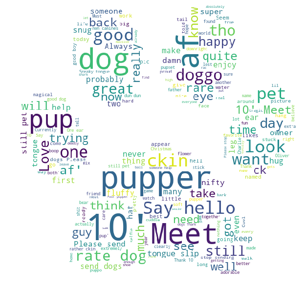

```python
gen_wc(text, mask)
```